# Statistical analyses

## GD and DP Relationship within species

Number of clusters in each species (from lowest to highest)

[output not shown]

### GD and PD relationship in 5 species with the most number of clusters

#### GD and PD relationship in 5 species with the most number of clusters

##### a) Panthera pardus

##### b) Panthera tigris

##### c) Panthera onca

##### d) Panthera leo

##### e) Puma concolor

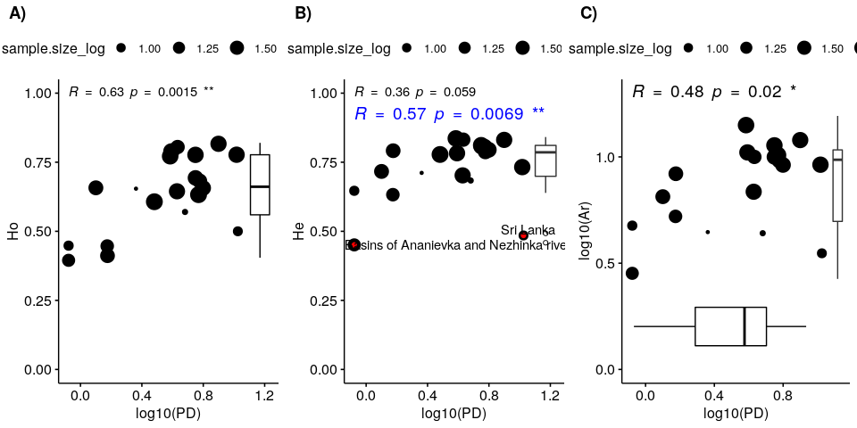

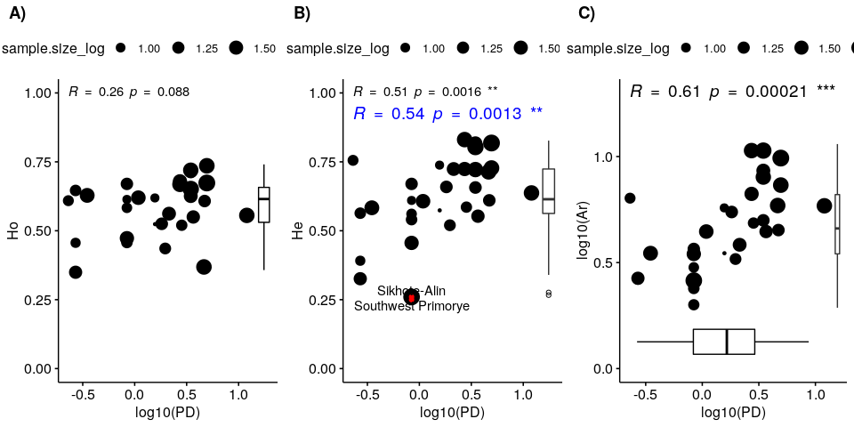

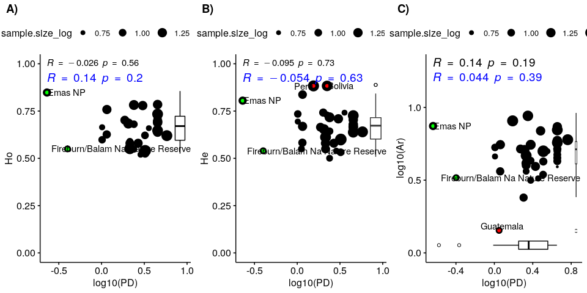

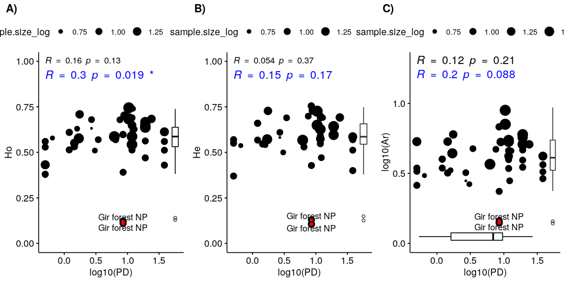

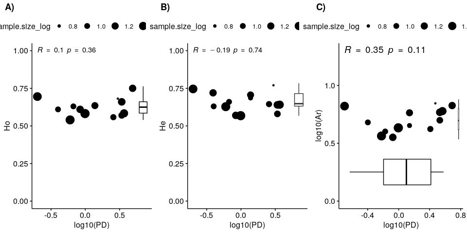

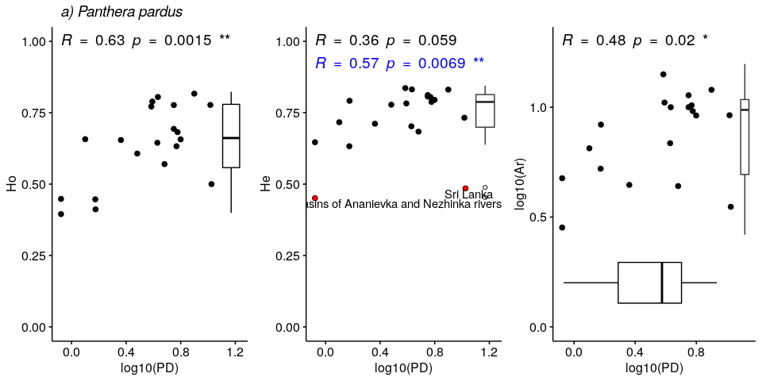

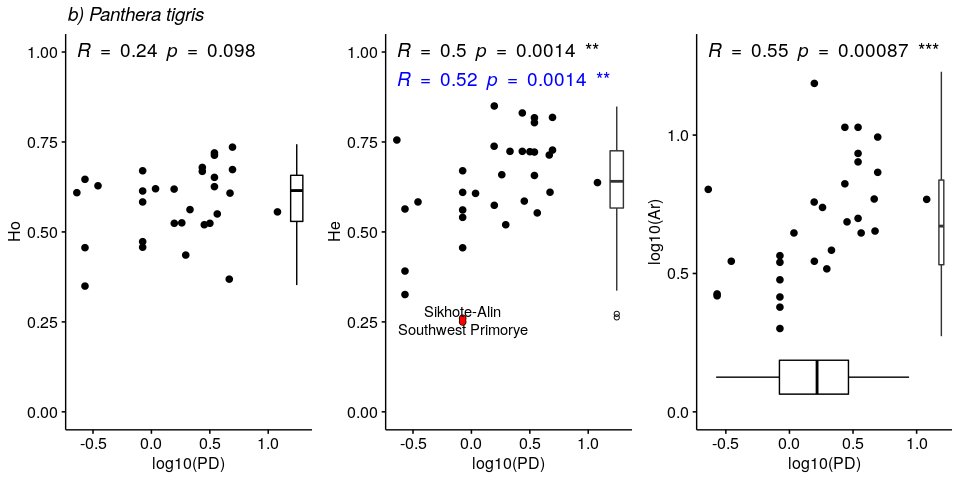

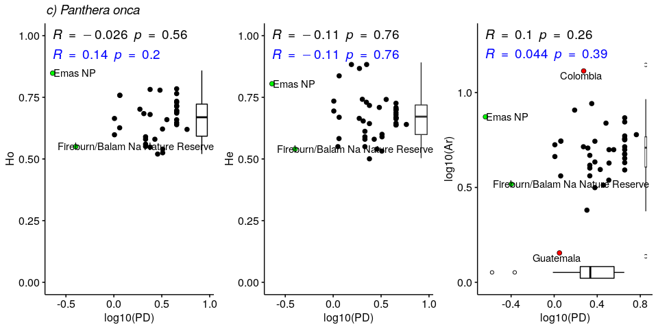

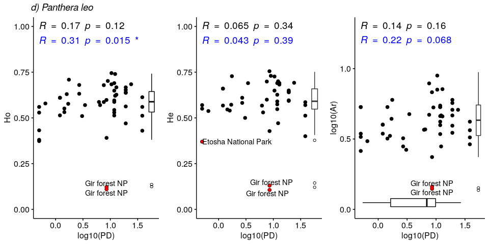

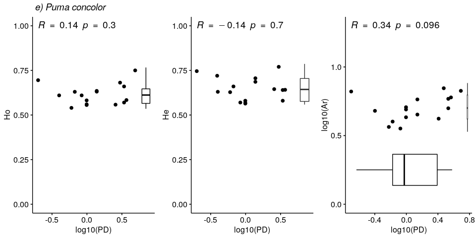

Red points represent the outliers in the GD data whereas green points are the outliers in the PD data.